# S670 Final Project

The Fantastic Four

Erik “Human Torch” Parker

Emily “Invisible Woman” Rudman

Vinay “The Thing” Vernekar

Jervis “Mister Fantastic” Wang

# Description of Data

**Data Sources** - Two primary data sources are:

1. **Catalog.data.gov** - The data contains details like store/restaurant proximity, food prices, community characteristics etc.
2. **Factfinder.census.gov** - Income details (median income) state and county level

**Important Variables**

**PCT_OBESE_ADULTS10** - The percentage of obese adults in a county in 2010.

**NATAMEN** - The Natural Amenities scale, is an index developed by the USDA in 1999 which ranges from 1 to 7 and measures the desirability of a particular location (here a county) based on natural factors.

**FSRPTH07** - Is the measure for full service restaurants in a county, per 1000 residents, in 2007.

**PCT_DIABETES_ADULTS10** - The percentage of adults that have diabetes in a county in 2010.

**Above** - A binary variable that assigns a 1 to a county who is above the national average obesity rate of 26.7% and 0 otherwise.

**Poverty Rate** - The poverty rate is the ratio of the number of people whose income falls below the poverty line.

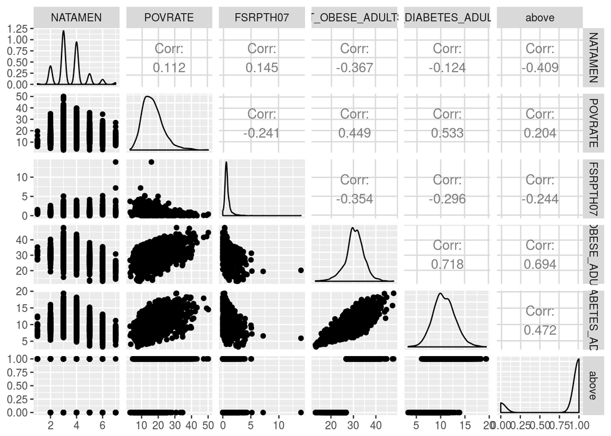

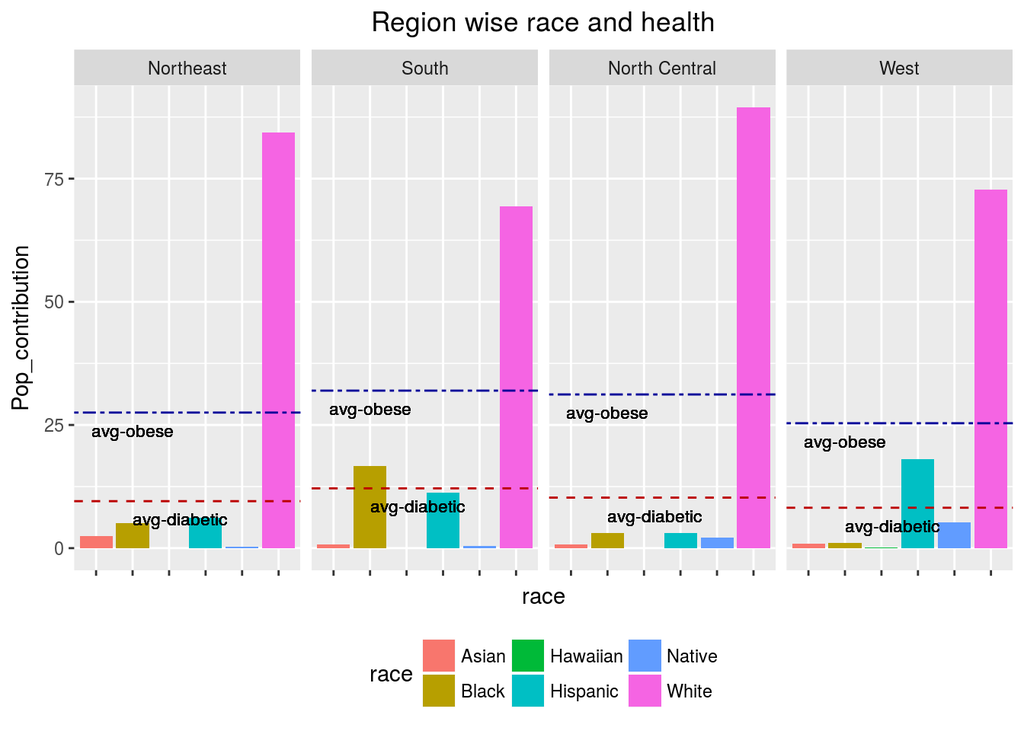

**Observations**  
1) Regions have considerable difference in the race diversity  
2) South and West regions have more diversity  
3) South region has more obese rate and diabetes rate

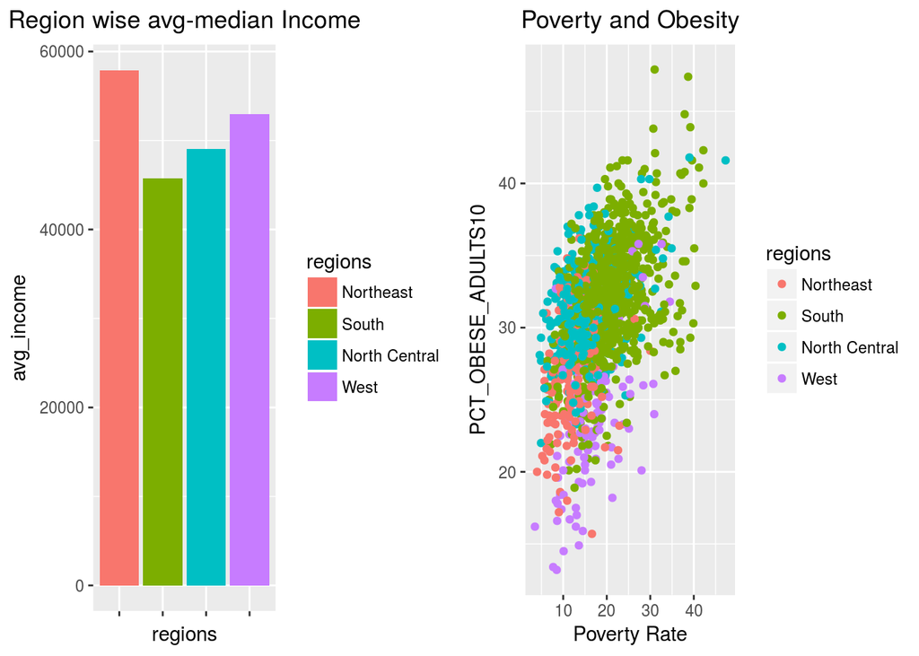

**Observations**  
1) South has the lowest avg median income level  
2) Earlier graphs indicate high obesity and diabetes rate in south  
3) The scatter chart clearly indicates some relationship between poverty and obesity

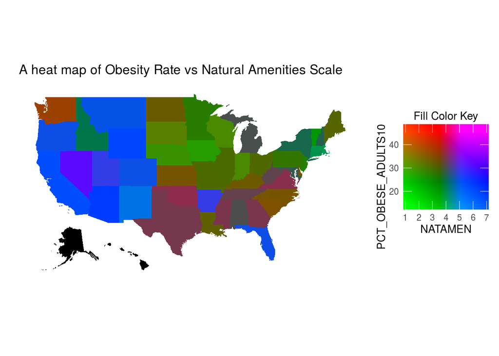

**Observations**  
1) In general there seems to be a regional relationship between both obesity rates and NATAMEN scores.  
2) High NATAMEN is generally matched by low obesity rates and vice versa.

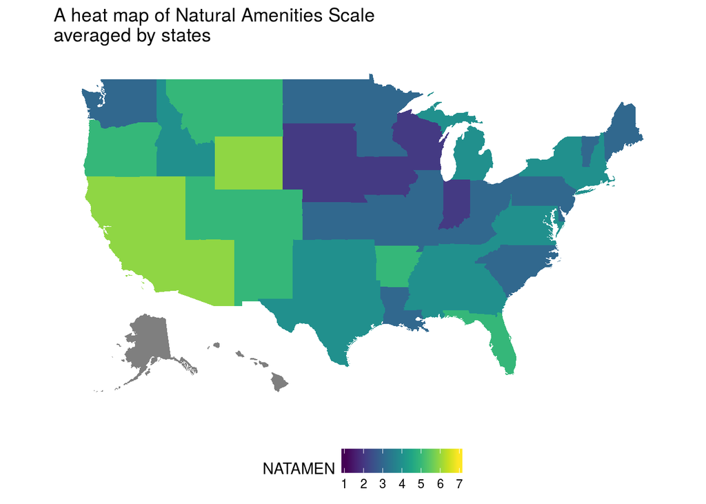

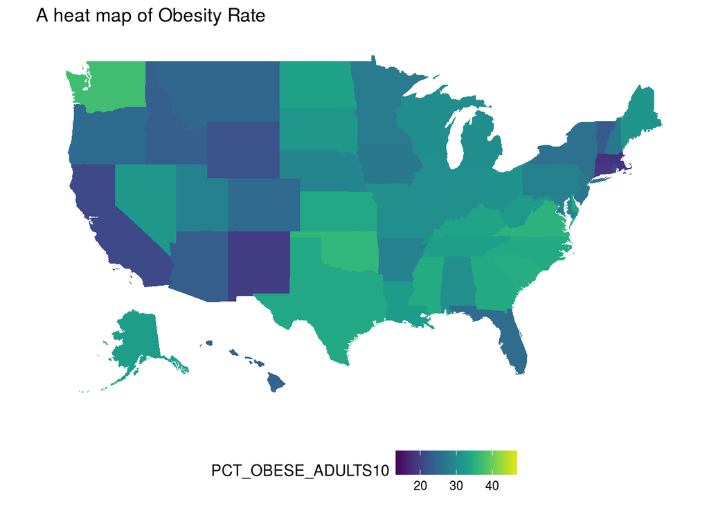

```r
model.ob <- glm(above ~ FSRPTH07 + NATAMEN + POVRATE10, family = "binomial",
    data = model.data)

# summary(model.ob)
```

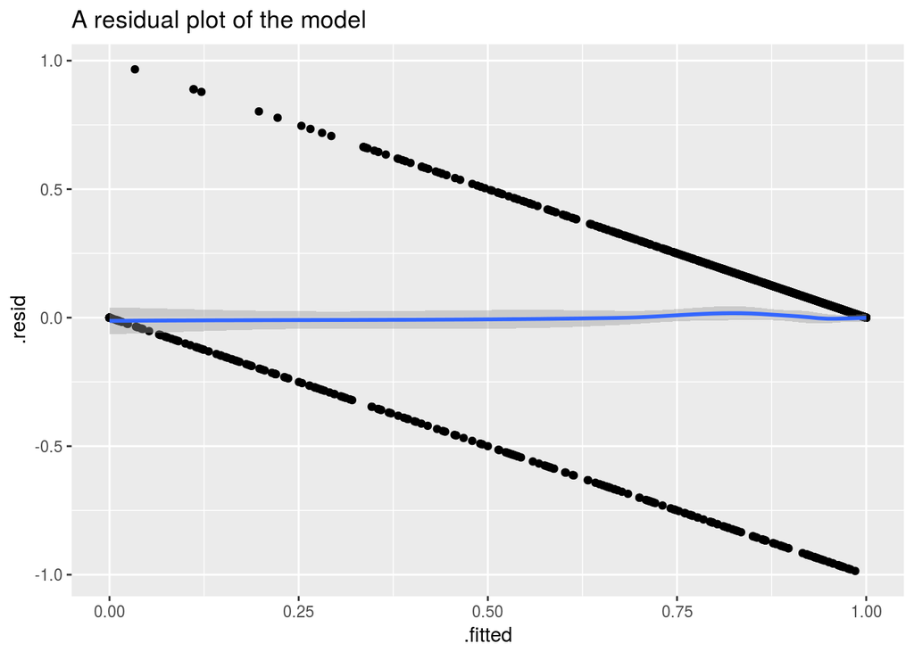

**Observations**  
1) Interactions were fitted, however none of these other alternative models lead to a significantly better fit or reduction in variance.  
2) Easy to interprete.  
3) Missing values were removed leading to loss of some original explanatory power.

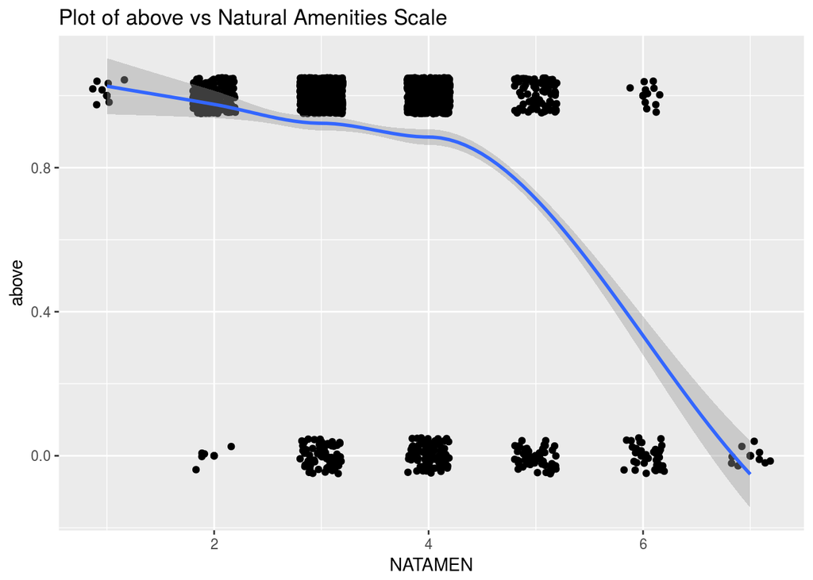

**Observations**  
1) There is a clear relationship between above and NATAMEN scores.  
2) No counties with a score of 1 are seen to be below average, and no counties with a score of 7 are above average.  
3) After reaching a NATAMEN score of 5, the majority of counties are above average but after this point, there is a quite sudden switch with counties largely being below average for obesity rate.  
4) The majorty of counties included in this analysis are above average for obesity.

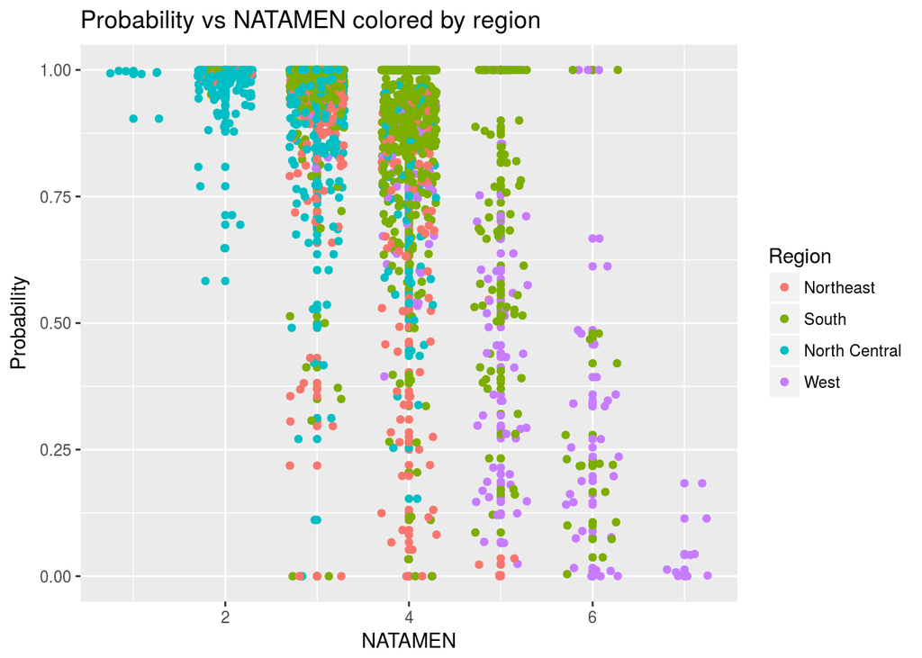

**Observations**  
1) West has highest NATAMEN and lowest probability  
2) North Central lowest NATAMEN, really high probabilities  
3) South moderate NATAMEN, relatively high probability  
4) Northeast very similar to South, with lower NATAMEN overall

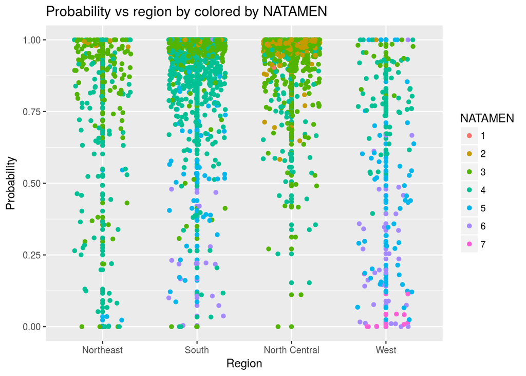

**Observations**  
1) Another view of previous plot, in general see lower NATAMEN values at high probabilities  
2) West with largest consistent range of probabilities

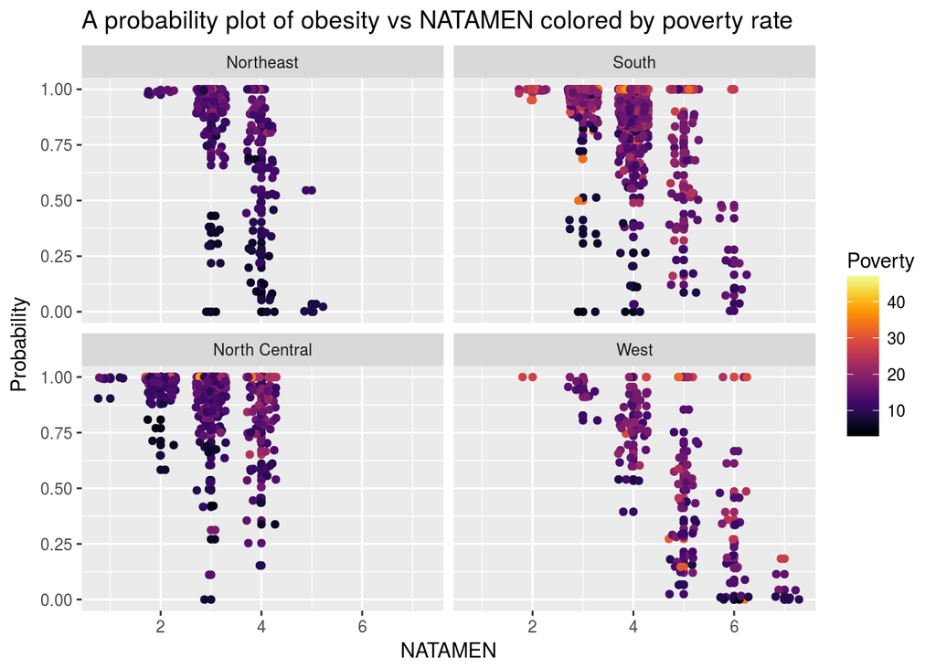

**Observations**  
1) South with generally high poverty and probability, wide range of NATAMEN  
2) West really mixed poverty rate, but generally low probabilities  
3) Northeast low poverty, high probabilities  
4) North Central like South, but lower poverty  
5) In general, seems to be lower probability with lower poverty

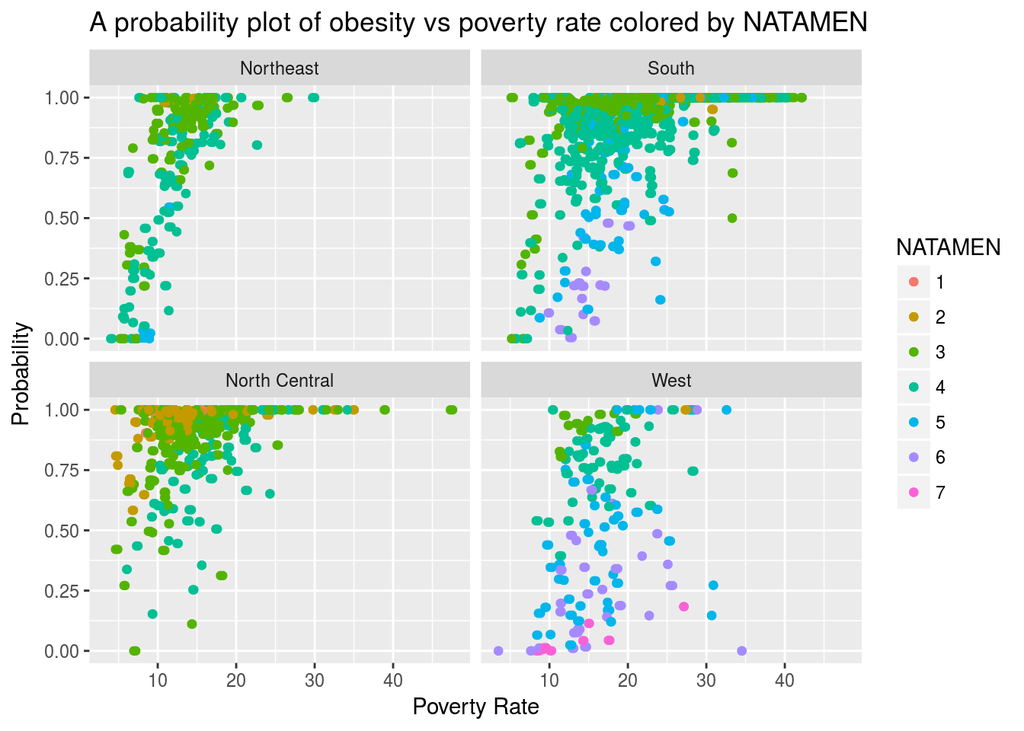

**Observations**  
1) See clearly increasing probability with increasing poverty in in all regions but west  
2) Also see some horizontal “bands” of probability by NATAMEN

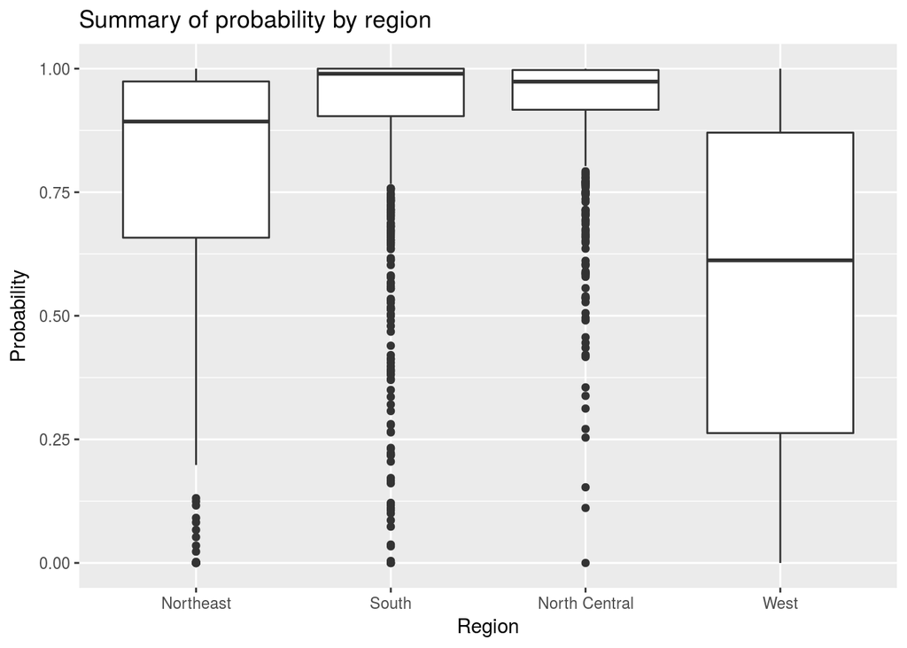

**Observations**  
1) Summary of previous figures: see large differences in probabilities by region.

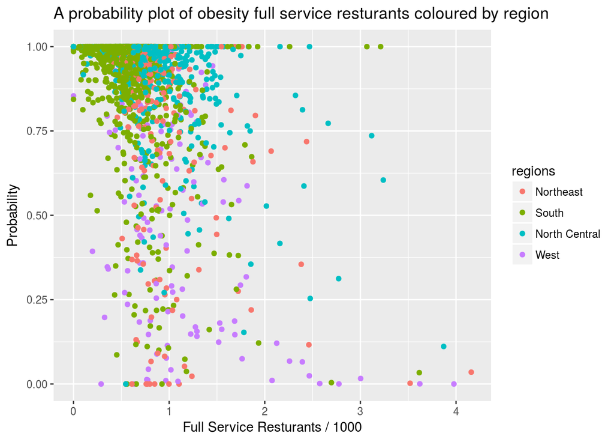

**Observations**  
1) Possibly some interaction going on? More resturants in West which has lower obesity. Not resturant number itself driving down rates, just a correlation?

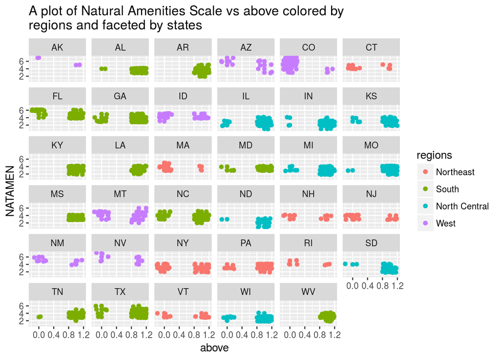

# Limitations

-We weren’t sure which type of diabetes this measures.  
-Didn’t report how they got the data.  
-This is an observational study so they had no control over the variables. We just looked for explanatory patterrs.  
-We had to take a a lot of NA and had to take out a bunch of data points ( only 35 states left).  
-The income reported is the median income for each county and has an error margin of +- 5%.  
-We would have liked more categories for the information they had.

# Conclusion

-We determined FSRPTH07, NATAMEN, and Poverty Rate were the three best variables to predict whether your county would be above and below obesity rate.  
-We made a good predictive model.  
-Don’t live in Kentucky.